# 第五章 机器学习系列

中国人民大学 统计学院  
周静

# 目录

- 机器学习概述
- 数据预处理
- 模型训练与调参
- 模型训练与集成

# 机器学习概述

- 机器学习的过程
  - 读入数据
  - 数据预处理及数据分割
  - 模型训练
  - 模型预测集评估

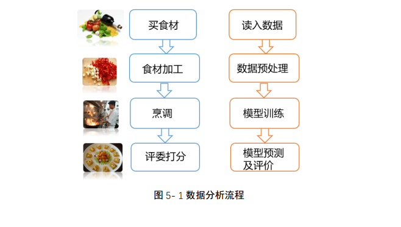

# 机器学习概述：载入数据和相应包

- caret 包
  - 为了解决预测问题的综合机器学习工具包
  - caret包中的机器学习算法依赖于其他包，比如随机森林算法要求安装randomForest包

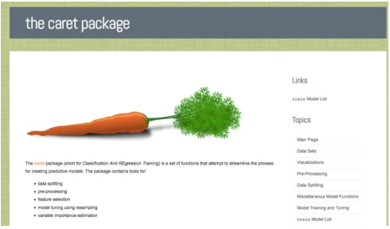

```r
##加载机器学习包
library(caret)
library(lattice)
library(ggplot2)
library(randomForest)
library(fastAdaboost)
```

# 数据预处理

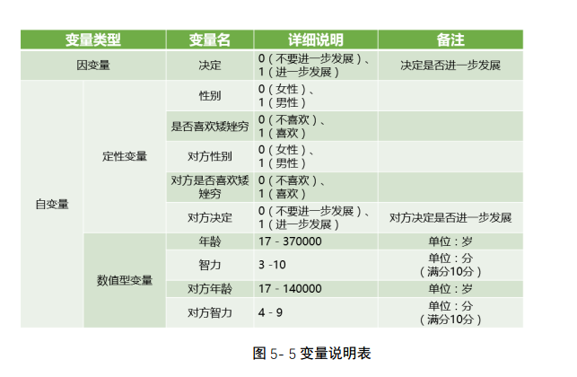

- 载入数据和加载包

```r
##加载机器学习包
library(caret)
## 加载数据
dat = read.csv('相亲数据2.csv')
dim(dat)
```

```
## [1] 15 12
```

```r
head(dat)
```

```
##   名字 决定 性别 是否喜欢矮矬穷   年龄 智力 对方名字 对方决定 对方性别
## 1 夜华    1    1              0  50000    9     白浅        1        0
## 2 白浅    0    0              0 140000    8     离镜        1        1
## 3 东华    0    1              0 360000   10     凤九        1        0
## 4 素锦    0    0              0  70000    5     离镜        0        1
## 5 离镜    1    1              0 140000    6     玄女        1        0
## 6 成玉    0    0              0    300    6     连宋        1        1
##   对方是否喜欢矮矬穷 对方年龄 对方智力
## 1                  0   140000        8
## 2                  0   140000        6
## 3                  0    30000        5
## 4                  0   140000        6
## 5                  0   100000        4
## 6                  0    90000        7
```

# 数据预处理：数据分割

划分训练集和测试集

- 留出法
  - 将样本分为两个互斥的子集
  - 通常情况，划分数据的80%为训练集，剩下的20%为测试集
  - caret 包：createDataPartition()函数可以保证训练集和测试集中Y的比例一致，会自动从y的各个level随机取出等比例的数据来组成训练集，可理解为分层抽样

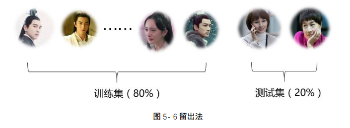

```r
###设置随机种子
set.seed(1234)
###将数据集的80%划分为训练集，20%划分为测试集
trainIndex = createDataPartition(dat$决定, p = .8, list = FALSE, times = 1)
datTrain = dat[ trainIndex,]        #训练集
datTest  = dat[-trainIndex,]        #测试集
table(dat$决定)/nrow(dat)           #全集上因变量各个水平的比例
```

```
##
##         0         1
## 0.5333333 0.4666667
```

```r
table(datTrain$决定)/nrow(datTrain) #训练集上因变量各个水平的比例
```

```
##
##         0         1
## 0.5833333 0.4166667
```

```r
table(datTest$决定)/nrow(datTest)   #测试集上因变量各个水平的比例
```

```
##
##         0         1
## 0.3333333 0.6666667
```

- 交叉验证法
  - 将原始数据分成 K 组（一般是均分）， 每次训练将其中一组作为测试集，另外 K-1 组作为训练集
  - 实际中，一般十折交叉验证用得最多
  - 示例数据量太少，以 3 折交叉验证为例

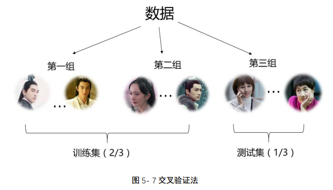

```r
set.seed(1234)
index = createFolds(dat$决定, k = 3, list = FALSE, returnTrain = TRUE)
index
```

```
##  [1] 2 3 2 1 1 1 1 3 2 1 3 3 2 3 2
```

```r
testIndex = which(index == 1)
datTraincv = dat[-testIndex , ]     #训练集
datTestcv  = dat[testIndex , ]      #测试集
```

- Bootstrap法
  - 数据量较少时适用
  - 从给定训练集中有放回的均匀抽样
  - createResample() 函数：times 参数用于设定生成几份随机样本

```r
set.seed(1234)
createResample(dat$决定, times = 3, list = F)
```

```
##       Resample1 Resample2 Resample3
##  [1,]         1         1         3
##  [2,]         2         1         4
##  [3,]         4         3         4
##  [4,]         5         3         4
##  [5,]         5         4         5
##  [6,]         8         4         5
##  [7,]         9         5         5
##  [8,]        10         5         7
##  [9,]        10         5         8
## [10,]        10         5         9
## [11,]        10         8        10
## [12,]        10        13        10
## [13,]        11        13        12
## [14,]        13        13        13
## [15,]        14        14        15
```

- 分割时间序列
  - createTimeSlices() 函数
  - 以time数据为例

```r
## 加载数据
growdata = read.csv('time.csv')
head(growdata)
```

```
##        时间 颜值
## 1 2016年1月    5
## 2 2016年2月    6
## 3 2016年3月    7
## 4 2016年4月    8
## 5 2016年5月    9
## 6 2016年6月   10
```

```r
timeSlices = createTimeSlices(1:nrow(growdata),
                               initialWindow = 5, horizon = 2, fixedWindow = TRUE)
timeSlices
```

```
## $train
## $train$Training5
## [1] 1 2 3 4 5
##
## $train$Training6
## [1] 2 3 4 5 6
##
##
## $test
## $test$Testing5
## [1] 6 7
##
## $test$Testing6
## [1] 7 8
```

# 数据预处理：处理缺失值

- preProcess()函数，三种方法
  - K近邻方法：会对原始数据进行标准化
  - Bagging树集成方法：对缺失值的填补更权威，但其效率比较低
  - 中位数法：速度非常快，但填补的准确率有待验证
- mice包，多重插补法
  - 基于MC（蒙特卡洛模拟法）

注意：只能用训练集信息，在此之前必须数据分割成训练集测试集

- 中位数法
  - 用训练集的中位数代替缺失值
  - 适用样本取值比较均匀的情况

```r
imputation_k = preProcess(datTrain,method = 'medianImpute')
datTrain1 =  predict(imputation_k, datTrain)
datTest1 =  predict(imputation_k, datTest)
datTest1
```

```
##      名字 决定 性别 是否喜欢矮矬穷 年龄 智力 对方名字 对方决定 对方性别
## 11   唐晶    0    0              0   36  8.0   陈俊生        0        1
## 12   宫羽    1    0              0   21  5.0   梅长苏        0        1
## 14 罗子君    1    0              0   35  8.5     贺函        1        1
##    对方是否喜欢矮矬穷 对方年龄 对方智力
## 11                  0       39        6
## 12                  0       31        9
## 14                  0       40        8
```

```r
median(datTrain$智力,na.rm = T)
```

```
## [1] 8.5
```

- K近邻方法
  - 基于欧氏距离计算 k 个和它最近的观测，然后接着利用 k 个近邻的数据来填补缺失值
  - K 近邻法会自动利用训练集的均值标准差信息对数据进行标准化
  - 会用训练集的mean和sd对测试集进行标准化

```r
library(RANN)
imputation_k = preProcess(datTrain,method = 'knnImpute')
datTrain1 =  predict(imputation_k, datTrain)
datTest1 =  predict(imputation_k, datTest)
datTrain$智力 = datTrain1$智力 * sd(datTrain$智力,na.rm = T) + mean(datTrain$智力,na.rm = T)
datTest$智力 = datTest1$智力 * sd(datTrain$智力,na.rm = T) + mean(datTrain$智力,na.rm = T)
datTest
```

```
##      名字 决定 性别 是否喜欢矮矬穷 年龄 智力 对方名字 对方决定 对方性别
## 11   唐晶    0    0              0   36  8.0   陈俊生        0        1
## 12   宫羽    1    0              0   21  5.0   梅长苏        0        1
## 14 罗子君    1    0              0   35  7.8     贺函        1        1
##    对方是否喜欢矮矬穷 对方年龄 对方智力
## 11                  0       39        6
## 12                  0       31        9
## 14                  0       40        8
```

- 处理0方差变量
  - 零方差、近零方差变量
  - nearZeroVar()函数：找出近零方差的变量

```r
#label为数字
dim(datTrain)
```

```
## [1] 12 12
```

```r
nzv = nearZeroVar(datTrain)
nzv
```

```
## [1]  4 10
```

```r
datTrain = datTrain[,-nzv]
```

- 处理高度线性相关变量
  - “性别”和“对方性别”
  - findCorrelation() 函数：找到高度共线性的变量，并给出建议删除的变量
  - 注：使用函数时，数据是不能有缺失值、只能包含数值型变量的dataframe或者matrix

```r
#数据中不能有NA
datTrain1 = datTrain[,-c(1,6)]
descrCor = cor(datTrain1)
descrCor
```

```
##                 决定       性别       年龄       智力    对方决定    对方性别
## 决定      1.00000000  0.2390457 -0.3627202 -0.1069045  0.09759001 -0.02857143
## 性别      0.23904572  1.0000000  0.2249529  0.6708204  0.00000000 -0.83666003
## 年龄     -0.36272022  0.2249529  1.0000000  0.4101776 -0.23058113 -0.33660090
## 智力     -0.10690450  0.6708204  0.4101776  1.0000000  0.12171612 -0.53452248
## 对方决定  0.09759001  0.0000000 -0.2305811  0.1217161  1.00000000  0.09759001
## 对方性别 -0.02857143 -0.8366600 -0.3366009 -0.5345225  0.09759001  1.00000000
## 对方年龄 -0.16239646 -0.4046800  0.2198356 -0.4162950 -0.10723488  0.21509188
## 对方智力  0.39266401 -0.1877293 -0.6989444  0.0000000  0.03832008  0.25803635
##            对方年龄    对方智力
## 决定     -0.1623965  0.39266401
## 性别     -0.4046800 -0.18772930
## 年龄      0.2198356 -0.69894438
## 智力     -0.4162950  0.00000000
## 对方决定 -0.1072349  0.03832008
## 对方性别  0.2150919  0.25803635
## 对方年龄  1.0000000 -0.25755521
## 对方智力 -0.2575552  1.00000000
```

```r
highlyCorDescr = findCorrelation(descrCor, cutoff = .75,names = F,verbose = T)
## Compare row 2  and column  6 with corr  0.837
##   Means:  0.366 vs 0.265 so flagging column 2
## All correlations <= 0.75
highlyCorDescr
```

```
## [1] 2
```

```r
filteredTrain = datTrain1[,-highlyCorDescr]
```

- 标准化
  - 量纲不同，防止某项权重过高
  - 利用训练集的均值和方差对测试集进行标准化

```r
preProcValues = preProcess(datTrain, method = c("center", "scale"))
trainTransformed = predict(preProcValues, datTrain)
testTransformed = predict(preProcValues, datTest)
```

# 模型训练与调参

- 调参的过程

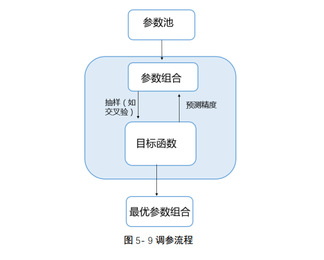

- 手动调参
  - 调参有风险，手动需谨慎
- 网格搜索
  - 有标准，将符合标准的参数放入参数池中，形成不同的参数组合
- 随机搜索
  - 随机搜索没有标准，随机地组合参数

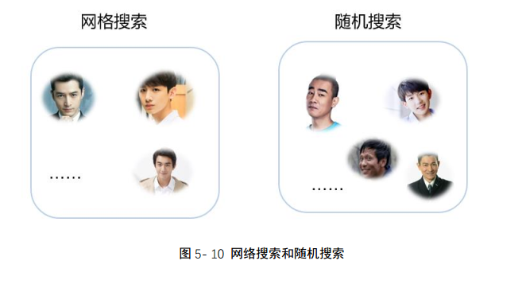

# 模型训练及调参：网格调参

- 网格搜索的实现
  - 设置随机种子，保证实验的可重复性
  - 利用 traincontrol函数设置模型训练时用到的参数
  - 设置网格搜索的参数池，也就是设定参数的选择范围
  - 利用 train函数来进行模型训练及得到最优参数组合

```r
set.seed(825)
fitControl = trainControl(method = "cv", number = 10,classProbs = TRUE,
                          summaryFunction = twoClassSummary)
gbmGrid =  expand.grid(interaction.depth = c(1, 5, 9), n.trees = (1:20)*20,
                        shrinkage = 0.1, n.minobsinnode = 20)
nrow(gbmGrid)
```

```
## [1] 60
```

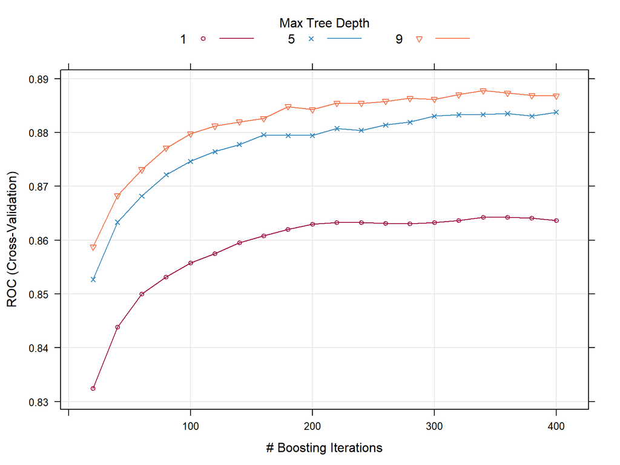

[figure not shown]

```r
gbmFit2 = train(决定 ~ ., data = dat.train, method = "gbm", trControl = fitControl,
                 verbose = FALSE, tuneGrid = gbmGrid,metric = "ROC")
gbmFit2
## Stochastic Gradient Boosting
##
## 4579 samples
##   28 predictor
##    2 classes: '拒绝', '接收'
##
## No pre-processing
## Resampling: Cross-Validated (10 fold)
## Summary of sample sizes: 4121, 4122, 4121, 4121, 4121, 4121, ...
## Resampling results across tuning parameters:
##
##   interaction.depth  n.trees  ROC        Sens       Spec
##   1                   20      0.8324111  0.7968248  0.6972489
##   1                   40      0.8438654  0.7835725  0.7304862
##   1                   60      0.8500325  0.7917543  0.7279962
##   1                   80      0.8531717  0.7905855  0.7339515
##   1                  100      0.8557872  0.7905855  0.7384094
##   1                  120      0.8574972  0.7921465  0.7438821
##   1                  140      0.8594954  0.7921449  0.7438821
##   1                  160      0.8607711  0.7909746  0.7493473
##   1                  180      0.8619932  0.7874681  0.7498350
##   1                  200      0.8629506  0.7898103  0.7488473
##   1                  220      0.8632841  0.7898088  0.7483498
##   1                  240      0.8633077  0.7933183  0.7473523
##   1                  260      0.8631474  0.7933153  0.7468548
##   1                  280      0.8630122  0.7952654  0.7473523
##   1                  300      0.8633065  0.7960466  0.7493399
##   1                  320      0.8636383  0.7940935  0.7488473
##   1                  340      0.8642211  0.7968294  0.7478523
##   1                  360      0.8642754  0.7948793  0.7458623
##   1                  380      0.8640697  0.7976091  0.7458573
##   1                  400      0.8636305  0.7972261  0.7448623
##   5                   20      0.8526908  0.8151553  0.7076449
##   5                   40      0.8633466  0.8065768  0.7334540
##   5                   60      0.8682031  0.8046237  0.7384144
##   5                   80      0.8721563  0.8100894  0.7473499
##   5                  100      0.8746409  0.8151538  0.7458647
##   5                  120      0.8764387  0.8155490  0.7498350
##   5                  140      0.8777762  0.8198368  0.7528151
##   5                  160      0.8795767  0.8190540  0.7587779
##   5                  180      0.8794625  0.8206195  0.7528176
##   5                  200      0.8794580  0.8210132  0.7553027
##   5                  220      0.8807483  0.8241352  0.7577829
##   5                  240      0.8804006  0.8229618  0.7577853
##   5                  260      0.8813896  0.8249088  0.7592705
##   5                  280      0.8819225  0.8280323  0.7552879
##   5                  300      0.8830493  0.8303715  0.7602630
##   5                  320      0.8833021  0.8249073  0.7597606
##   5                  340      0.8833446  0.8268589  0.7677085
##   5                  360      0.8835188  0.8284229  0.7557879
##   5                  380      0.8830482  0.8264667  0.7607507
##   5                  400      0.8837798  0.8311482  0.7587631
##   9                   20      0.8587391  0.8143710  0.7190508
##   9                   40      0.8682940  0.8116473  0.7324688
##   9                   60      0.8731075  0.8182834  0.7473647
##   9                   80      0.8771064  0.8159487  0.7582705
##   9                  100      0.8797453  0.8206271  0.7612531
##   9                  120      0.8812097  0.8264667  0.7587582
##   9                  140      0.8819674  0.8295948  0.7627383
##   9                  160      0.8826086  0.8327167  0.7627309
##   9                  180      0.8848144  0.8311558  0.7691838
##   9                  200      0.8842609  0.8272480  0.7696887
##   9                  220      0.8854727  0.8323261  0.7667258
##   9                  240      0.8854283  0.8331028  0.7687010
##   9                  260      0.8857922  0.8338795  0.7701911
##   9                  280      0.8863387  0.8342838  0.7686887
##   9                  300      0.8861660  0.8354481  0.7667159
##   9                  320      0.8870337  0.8342747  0.7696813
##   9                  340      0.8877804  0.8331013  0.7691789
##   9                  360      0.8873535  0.8350514  0.7677036
##   9                  380      0.8869007  0.8311573  0.7681863
##   9                  400      0.8868318  0.8327137  0.7706714
##
## Tuning parameter 'shrinkage' was held constant at a value of 0.1
##
## Tuning parameter 'n.minobsinnode' was held constant at a value of 20
## ROC was used to select the optimal model using the largest value.
## The final values used for the model were n.trees = 340, interaction.depth =
##  9, shrinkage = 0.1 and n.minobsinnode = 20.
##画图
trellis.par.set(caretTheme())
plot(gbmFit2)
```

# 模型训练及调参： 随机调参

- 随机搜索的实现
  - 设定随机种子
  - trainControl 函数设定模型训练的参数：search=“random”
  - 无须设置 tuneGrid 参数，只需要设置参数 tuneLength（随机搜索多少组）
  - 利用 train 函数来进行模型训练及得到最优参数组合

```r
set.seed(825)
fitControl = trainControl(method = "cv",number = 10,classProbs = TRUE,
                          summaryFunction = twoClassSummary,search = "random")
gbmFit3 = train(决定 ~ ., data = dat.train, method = "gbm", trControl = fitControl,
                 verbose = FALSE, metric = "ROC",tuneLength = 10)
gbmFit3
## Stochastic Gradient Boosting
##
## 4579 samples
##   28 predictor
##    2 classes: '拒绝', '接收'
##
## No pre-processing
## Resampling: Cross-Validated (10 fold)
## Summary of sample sizes: 4121, 4122, 4121, 4121, 4121, 4121, ...
## Resampling results across tuning parameters:
##
##   shrinkage   interaction.depth  n.minobsinnode  n.trees  ROC        Sens
##   0.02003546  8                  19              1254     0.8898858  0.8299824
##   0.02417047  5                  23               672     0.8809586  0.8202274
##   0.07522320  7                  21              2902     0.8858505  0.8381597
##   0.17831481  2                  25              1191     0.8767407  0.8135989
##   0.20246499  3                  25              2824     0.8759405  0.8241230
##   0.25137467  9                  12               963     0.8827680  0.8299656
##   0.30943419  5                   8              2800     0.8796046  0.8217519
##   0.32458368  3                  18              3610     0.8671118  0.8143604
##   0.40284000  5                  17              1415     0.8718084  0.8182667
##   0.59309733  6                  11              4054     0.8777650  0.8276295
##   Spec
##   0.7711615
##   0.7513275
##   0.7686986
##   0.7632284
##   0.7602680
##   0.7542781
##   0.7632506
##   0.7483572
##   0.7548126
##   0.7726861
##
## ROC was used to select the optimal model using the largest value.
## The final values used for the model were n.trees = 1254, interaction.depth =
##  8, shrinkage = 0.02003546 and n.minobsinnode = 19.
```

# 模型预测及评价

- predict() 函数
- 混淆矩阵（Confusion Matrix）：confusionMatrix() 函数

```r
##网格搜索
data.predict = predict(gbmFit2, newdata = dat.test)
confusionMatrix(data.predict,dat.test$决定)
## Confusion Matrix and Statistics
##
##           Reference
## Prediction 拒绝 接收
##       拒绝  521  107
##       接收  120  396
##
##                Accuracy : 0.8016
##                  95% CI : (0.7773, 0.8243)
##     No Information Rate : 0.5603
##     P-Value [Acc > NIR] : <2e-16
##
##                   Kappa : 0.5984
##
##  Mcnemar's Test P-Value : 0.4258
##
##             Sensitivity : 0.8128
##             Specificity : 0.7873
##          Pos Pred Value : 0.8296
##          Neg Pred Value : 0.7674
##              Prevalence : 0.5603
##          Detection Rate : 0.4554
##    Detection Prevalence : 0.5490
##       Balanced Accuracy : 0.8000
##
##        'Positive' Class : 拒绝
##
##随机搜索
data.predict = predict(gbmFit3, newdata = dat.test)
confusionMatrix(data.predict,dat.test$决定)
## Confusion Matrix and Statistics
##
##           Reference
## Prediction 拒绝 接收
##       拒绝  519   99
##       接收  122  404
##
##                Accuracy : 0.8068
##                  95% CI : (0.7827, 0.8293)
##     No Information Rate : 0.5603
##     P-Value [Acc > NIR] : <2e-16
##
##                   Kappa : 0.6099
##
##  Mcnemar's Test P-Value : 0.1389
##
##             Sensitivity : 0.8097
##             Specificity : 0.8032
##          Pos Pred Value : 0.8398
##          Neg Pred Value : 0.7681
##              Prevalence : 0.5603
##          Detection Rate : 0.4537
##    Detection Prevalence : 0.5402
##       Balanced Accuracy : 0.8064
##
##        'Positive' Class : 拒绝
##
```

# 模型训练与集成：模型训练

利用不同模型来提高预测精度

- 逻辑回归
  - 度量 Y=1 的可能性
  - - method 参数为“glm”

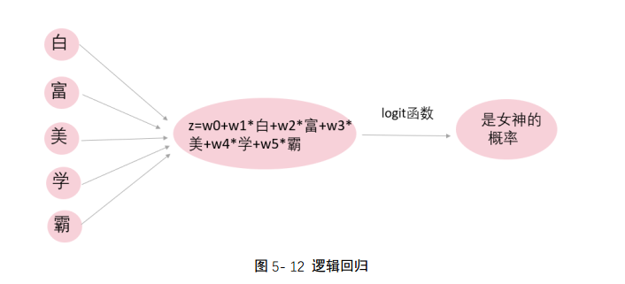

```r
fit1 = train(决定 ~ ., data = dat.train, method = "glm",family="binomial")  #训练模型
pstate1 = predict(fit1, newdata = dat.test)  #在测试集上预测
confusionMatrix(pstate1, dat.test$决定)      #利用混淆矩阵评估模型
## Confusion Matrix and Statistics
##
##           Reference
## Prediction 拒绝 接收
##       拒绝  514  114
##       接收  127  389
##
##                Accuracy : 0.7893
##                  95% CI : (0.7645, 0.8126)
##     No Information Rate : 0.5603
##     P-Value [Acc > NIR] : <2e-16
##
##                   Kappa : 0.5736
##
##  Mcnemar's Test P-Value : 0.4395
##
##             Sensitivity : 0.8019
##             Specificity : 0.7734
##          Pos Pred Value : 0.8185
##          Neg Pred Value : 0.7539
##              Prevalence : 0.5603
##          Detection Rate : 0.4493
##    Detection Prevalence : 0.5490
##       Balanced Accuracy : 0.7876
##
##        'Positive' Class : 拒绝
##
```

- 决策树
  - method 参数为“rpart”

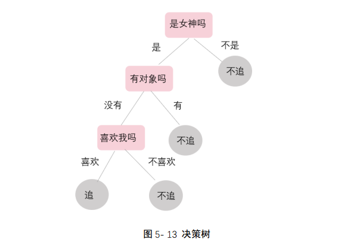

```r
fit2 = train(决定 ~ ., data = dat.train,
               method = "rpart")  #训练模型
pstate2 = predict(fit2, newdata = dat.test) #在测试集上预测
confusionMatrix(pstate2, dat.test$决定) #利用混淆矩阵评估模型
## Confusion Matrix and Statistics
##
##           Reference
## Prediction 拒绝 接收
##       拒绝  566  175
##       接收   75  328
##
##                Accuracy : 0.7815
##                  95% CI : (0.7564, 0.8051)
##     No Information Rate : 0.5603
##     P-Value [Acc > NIR] : < 2.2e-16
##
##                   Kappa : 0.5468
##
##  Mcnemar's Test P-Value : 3.818e-10
##
##             Sensitivity : 0.8830
##             Specificity : 0.6521
##          Pos Pred Value : 0.7638
##          Neg Pred Value : 0.8139
##              Prevalence : 0.5603
##          Detection Rate : 0.4948
##    Detection Prevalence : 0.6477
##       Balanced Accuracy : 0.7675
##
##        'Positive' Class : 拒绝
##
```

- 随机森林
  - 多棵决策树集成，基本单元为决策树
  - method 参数为“rf”

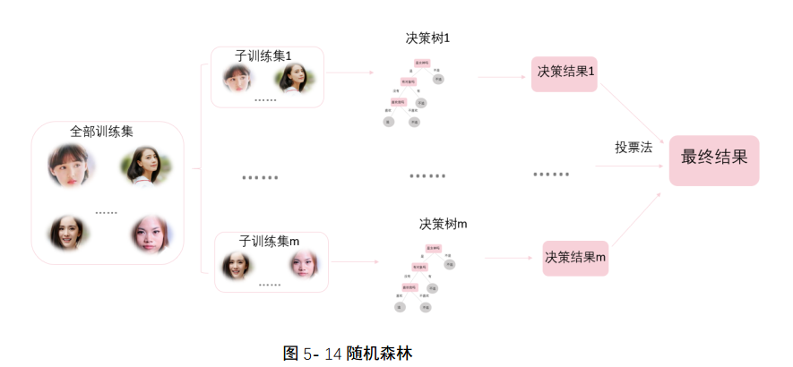

```r
set.seed(1234)
fit3 = train(决定 ~ ., data = dat.train, method = "rf")  #训练模型
pstate3 = predict(fit3, newdata = dat.test) #在测试集上预测
confusionMatrix(pstate3, dat.test$决定) #利用混淆矩阵评估模型
## Confusion Matrix and Statistics
##
##           Reference
## Prediction 拒绝 接收
##       拒绝  524  119
##       接收  117  384
##
##                Accuracy : 0.7937
##                  95% CI : (0.7691, 0.8168)
##     No Information Rate : 0.5603
##     P-Value [Acc > NIR] : <2e-16
##
##                   Kappa : 0.5811
##
##  Mcnemar's Test P-Value : 0.9481
##
##             Sensitivity : 0.8175
##             Specificity : 0.7634
##          Pos Pred Value : 0.8149
##          Neg Pred Value : 0.7665
##              Prevalence : 0.5603
##          Detection Rate : 0.4580
##    Detection Prevalence : 0.5621
##       Balanced Accuracy : 0.7904
##
##        'Positive' Class : 拒绝
##
```

# 模型训练与集成：模型集成

- 思想：一个分类器学习可能会犯错，多个分类器一起学习可能会取长补短
- 投票法
  - 适用于分类问题
  - 思想：“少数服从多数”
  - 问题：可能有“猪队友”拉后腿

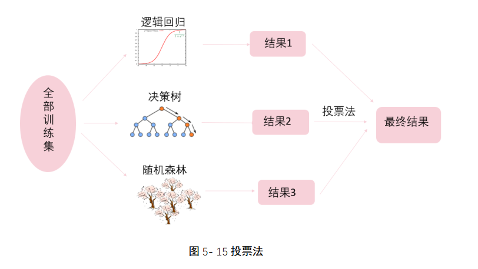

```r
results = data.frame(pstate1, pstate2,  pstate3)
results = apply(results,2,as.character)
major_results = apply(results, 1, function(x){
  tb = sort(table(x),decreasing = T)
  if(tb[1] %in% tb[2]){
    return(sample(c(names(tb)[1],names(tb)[2]),1))
  }else{ return(names(tb)[1]) }
})
major_results = factor(major_results,levels = c("拒绝","接收"))
confusionMatrix(major_results, dat.test$决定)
## Confusion Matrix and Statistics
##
##           Reference
## Prediction 拒绝 接收
##       拒绝  532  129
##       接收  109  374
##
##                Accuracy : 0.792
##                  95% CI : (0.7673, 0.8151)
##     No Information Rate : 0.5603
##     P-Value [Acc > NIR] : <2e-16
##
##                   Kappa : 0.576
##
##  Mcnemar's Test P-Value : 0.2181
##
##             Sensitivity : 0.8300
##             Specificity : 0.7435
##          Pos Pred Value : 0.8048
##          Neg Pred Value : 0.7743
##              Prevalence : 0.5603
##          Detection Rate : 0.4650
##    Detection Prevalence : 0.5778
##       Balanced Accuracy : 0.7867
##
##        'Positive' Class : 拒绝
##
```

- 堆叠集成法
  - 首先利用机器学习的不同模型得到不同预测结果
  - 将不同模型得到的预测结果作为自变量输入模型进行拟合

[figure not shown]

```r
set.seed(1234)
combPre = data.frame(pstate1, pstate2, pstate3,决定 = dat.test$决定)
combfit = train(决定~., method = "rf", data = combPre)
## note: only 2 unique complexity parameters in default grid. Truncating the grid to 2 .
combpstate = predict(combfit, newdata = dat.test)
confusionMatrix(combpstate, dat.test$决定)
## Confusion Matrix and Statistics
##
##           Reference
## Prediction 拒绝 接收
##       拒绝  542  126
##       接收   99  377
##
##                Accuracy : 0.8033
##                  95% CI : (0.7791, 0.826)
##     No Information Rate : 0.5603
##     P-Value [Acc > NIR] : < 2e-16
##
##                   Kappa : 0.5985
##
##  Mcnemar's Test P-Value : 0.08304
##
##             Sensitivity : 0.8456
##             Specificity : 0.7495
##          Pos Pred Value : 0.8114
##          Neg Pred Value : 0.7920
##              Prevalence : 0.5603
##          Detection Rate : 0.4738
##    Detection Prevalence : 0.5839
##       Balanced Accuracy : 0.7975
##
##        'Positive' Class : 拒绝
##
```

- AdaBoost
  - 区别对待不同训练样本
  - 对所有训练样本都赋予相等的权重
  - 对每个训练样本都进行训练，得到训练精度
  - 对训练精度低的样本赋予更大的权重，让模型能更注意提高这部分样本的训练精度
  - 将各个样本训练出来的结果进行加权投票或加权平均

```r
set.seed(1234)
fit4 = train(决定 ~ ., data = dat.train,
               method = "adaboost")  #训练模型
pstate4 = predict(fit4, newdata = dat.test) #在测试集上预测
confusionMatrix(pstate4, dat.test$决定) #利用混淆矩阵评估模型
## Confusion Matrix and Statistics
##
##           Reference
## Prediction 拒绝 接收
##       拒绝  528  106
##       接收  113  397
##
##                Accuracy : 0.8086
##                  95% CI : (0.7845, 0.831)
##     No Information Rate : 0.5603
##     P-Value [Acc > NIR] : <2e-16
##
##                   Kappa : 0.6121
##
##  Mcnemar's Test P-Value : 0.6852
##
##             Sensitivity : 0.8237
##             Specificity : 0.7893
##          Pos Pred Value : 0.8328
##          Neg Pred Value : 0.7784
##              Prevalence : 0.5603
##          Detection Rate : 0.4615
##    Detection Prevalence : 0.5542
##       Balanced Accuracy : 0.8065
##
##        'Positive' Class : 拒绝
##
```

[figure not shown]